# Assignment 03 - Web Scraping and Text Mining

liyongsh@usc.edu

```r
knitr::opts_chunk$set(include  = TRUE, echo=FALSE)
library(xml2)
library(stringr)
library(httr)
library(tidyverse)
```

# APIs

- Using the NCBI API, look for papers that show up under the term “sars-cov-2 trial vaccine.” Look for the data in the pubmed database, and then retrieve the details of the paper as shown in lab 7. How many papers were you able to find?

```
## [1] "564"
```

I am able to find 564 papers.

- Using the list of pubmed ids you retrieved, download each papers’ details using the query parameter rettype = abstract. If you get more than 250 ids, just keep the first 250.
- As we did in lab 7. Create a dataset containing the following:
1. Pubmed ID number,
2. Title of the paper,
3. Name of the journal where it was published,
4. Publication date, and
5. Abstract of the paper (if any).

**Only the first five data records are shown**

| PubMedID | Title | Journal | Date | Abstracts |
| --- | --- | --- | --- | --- |
| 32998488 | Status of COVID-19 vaccine development. | Tidsskrift for den Norske laegeforening : tidsskrift for praktisk medicin, ny raekke | 2020 09 29 | NA |
| 32998157 | COVID-19 vaccine BNT162b1 elicits human antibody and TH1 T-cell responses. | Nature | 2020 Sep 30 | An effective vaccine is needed to halt the spread of the severe acute respiratory syndrome coronavirus-2 (SARS-CoV-2) pandemic. Recently, we reported safety, tolerability and antibody response data fr… |
| 32997699 | Analysis of COVID-19 clinical trials: A data-driven, ontology-based, and natural language processing approach. | PloS one | 2020 | With the novel COVID-19 pandemic disrupting and threatening the lives of millions, researchers and clinicians have been recently conducting clinical trials at an unprecedented rate to learn more about… |
| 32994572 | COVID vaccine confidence requires radical transparency. | Nature | 2020 10 | NA |
| 32991794 | Safety and Immunogenicity of SARS-CoV-2 mRNA-1273 Vaccine in Older Adults. | The New England journal of medicine | 2020 Sep 29 | Testing of vaccine candidates to prevent infection with severe acute respiratory syndrome coronavirus 2 (SARS-CoV-2) in an older population is important, since increased incidences of illness and deat… |

# Text Mining

A new dataset has been added to the data science data repository https://github.com/USCbiostats/data-science-data/tree/master/03_pubmed. The dataset contains 3241 abstracts from articles across 5 search terms. Your job is to analyse these abstracts to find interesting insights.

Tokenize the abstracts and count the number of each token. Do you see anything interesting? Does removing stop words change what tokens appear as the most frequent? What are the 5 most common tokens for each search term after removing stopwords?

```
## # A tibble: 20,567 x 2
##    word      n
##    <chr> <int>
##  1 the   28126
##  2 of    24760
##  3 and   19993
##  4 in    14653
##  5 to    10920
##  6 a      8245
##  7 with   8038
##  8 covid  7275
##  9 19     7080
## 10 is     5649
## # … with 20,557 more rows
```

Before removing stop words, the tokenized words are not informative, top words are the, of, and, etc. They are not interesting.

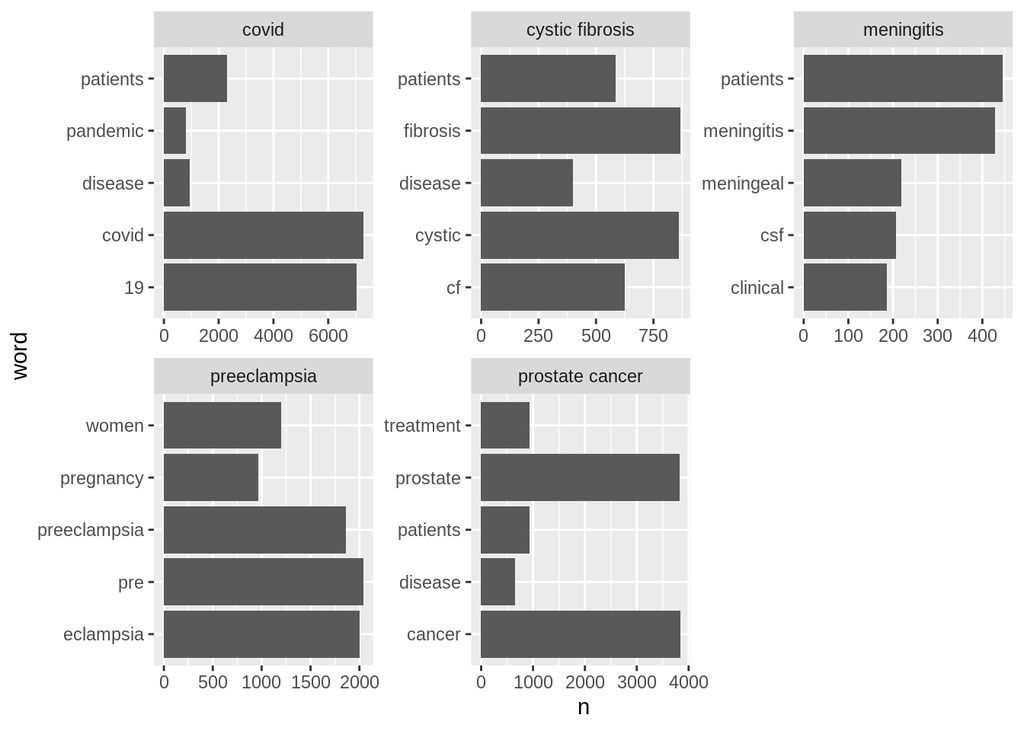

Removing stop words significantly change what appear as the most frequent. The 5 most common tokens for each search term after removing stopwords are shown in the graph.

Tokenize the abstracts into bigrams. Find the 10 most common bigram and visualize them with ggplot2.

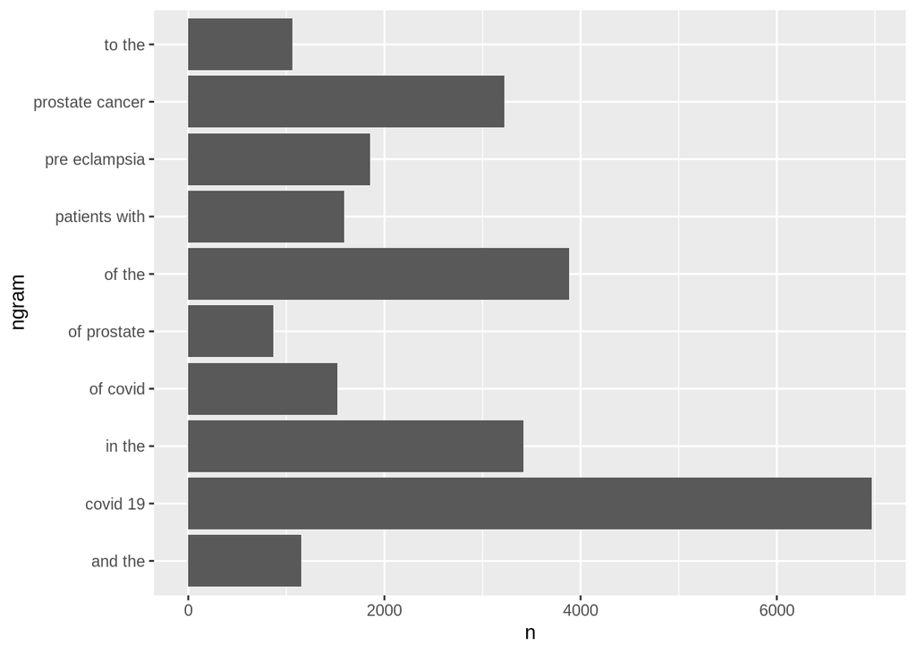

Calculate the TF-IDF value for each word-search term combination. (here you want the search term to be the “document”) What are the 5 tokens from each search term with the highest TF-IDF value? How are the results different from the answers you got in question 1?

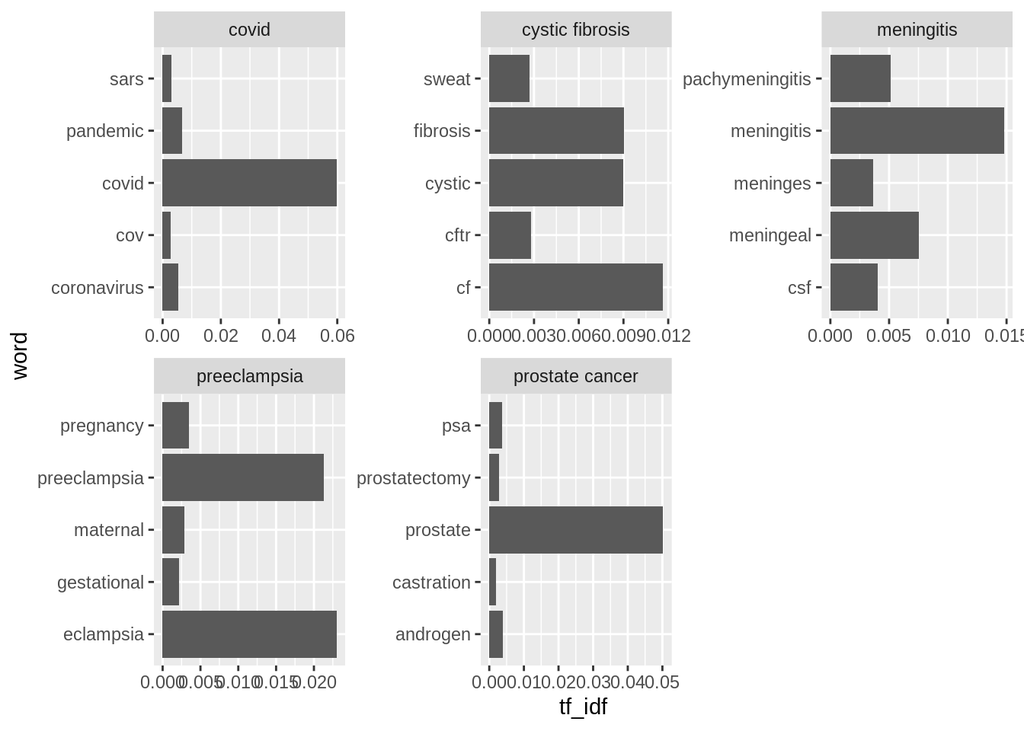

The 5 tokens from each search term with the highest IF_IDF value is shown in the graph. The results are different with that of the question 1 because they are more informative and more related with the search term. TF_IDF may be more effective than simple word counts since it intergrates the IDF which can downweight the importance of TF.